# **UE20CS631 - Data Analytics** **Worksheet 1a - Part 2: Exploring Data with R** SRN - PES1UG20CS620 NAME - Adarsh Subhas Nayak WORKSHEET 1A PART 2

Name: Adarsh S Nayak  
SRN : PES1UG20CS620 —-

## —

```r
library(tidyverse)
data<- read_csv("CharlesBookClubDataset.csv")
```

```
## ──────────────────────────────────────────────────────── Delimiter: "," chr
## (4): Name, Phone_No., Address, Job dbl (22): ...1, Seq#, ID#, Gender, M, R, F,
## FirstPurch, ChildBks, YouthBks, ...
```

```r
data1<-read_csv("CharlesBookClubDataset.csv")
```

```
## ──────────────────────────────────────────────────────── Delimiter: "," chr
## (4): Name, Phone_No., Address, Job dbl (22): ...1, Seq#, ID#, Gender, M, R, F,
## FirstPurch, ChildBks, YouthBks, ...
```

#problem 1 (1 point) Generate an understanding of the dataset via a summary of its features. Find the count, missing count,minimum, 1st quartile, median, mean, 3rd quartile, max and standard deviation of all relevant columns ,Separately, print the total number of missing values in each column.

```r
summary(data1)
```

```
##       ...1             Seq#           ID#            Gender
##  Min.   :   0.0   Min.   :   1   Min.   :   25   Min.   :0.0000
##  1st Qu.: 999.8   1st Qu.:1001   1st Qu.: 8253   1st Qu.:0.0000
##  Median :1999.5   Median :2000   Median :16581   Median :1.0000
##  Mean   :1999.5   Mean   :2000   Mean   :16595   Mean   :0.7045
##  3rd Qu.:2999.2   3rd Qu.:3000   3rd Qu.:24838   3rd Qu.:1.0000
##  Max.   :3999.0   Max.   :4000   Max.   :32977   Max.   :1.0000
##
##        M               R               F            FirstPurch
##  Min.   : 15.0   Min.   : 2.00   Min.   : 1.000   Min.   : 2.00
##  1st Qu.:130.0   1st Qu.: 8.00   1st Qu.: 1.000   1st Qu.:12.00
##  Median :208.0   Median :12.00   Median : 2.000   Median :20.00
##  Mean   :208.2   Mean   :13.43   Mean   : 3.831   Mean   :26.51
##  3rd Qu.:283.0   3rd Qu.:16.00   3rd Qu.: 6.000   3rd Qu.:36.00
##  Max.   :479.0   Max.   :36.00   Max.   :12.000   Max.   :99.00
##  NA's   :93      NA's   :342     NA's   :218
##     ChildBks         YouthBks         CookBks          DoItYBks
##  Min.   :0.0000   Min.   :0.0000   Min.   :0.0000   Min.   :0.0000
##  1st Qu.:0.0000   1st Qu.:0.0000   1st Qu.:0.0000   1st Qu.:0.0000
##  Median :0.0000   Median :0.0000   Median :0.0000   Median :0.0000
##  Mean   :0.6398   Mean   :0.3048   Mean   :0.7312   Mean   :0.3508
##  3rd Qu.:1.0000   3rd Qu.:0.0000   3rd Qu.:1.0000   3rd Qu.:1.0000
##  Max.   :7.0000   Max.   :5.0000   Max.   :7.0000   Max.   :5.0000
##
##      RefBks           ArtBks         GeogBks          ItalCook
##  Min.   :0.0000   Min.   :0.000   Min.   :0.0000   Min.   :0.0000
##  1st Qu.:0.0000   1st Qu.:0.000   1st Qu.:0.0000   1st Qu.:0.0000
##  Median :0.0000   Median :0.000   Median :0.0000   Median :0.0000
##  Mean   :0.2562   Mean   :0.289   Mean   :0.3875   Mean   :0.1252
##  3rd Qu.:0.0000   3rd Qu.:0.000   3rd Qu.:1.0000   3rd Qu.:0.0000
##  Max.   :4.0000   Max.   :5.000   Max.   :6.0000   Max.   :3.0000
##
##    ItalAtlas         ItalArt           Florence      Related Purchase
##  Min.   :0.0000   Min.   :0.00000   Min.   :0.0000   Min.   :0.000
##  1st Qu.:0.0000   1st Qu.:0.00000   1st Qu.:0.0000   1st Qu.:0.000
##  Median :0.0000   Median :0.00000   Median :0.0000   Median :0.000
##  Mean   :0.0375   Mean   :0.04575   Mean   :0.0845   Mean   :0.885
##  3rd Qu.:0.0000   3rd Qu.:0.00000   3rd Qu.:0.0000   3rd Qu.:1.000
##  Max.   :2.0000   Max.   :2.00000   Max.   :1.0000   Max.   :8.000
##
##   Yes_Florence     No_Florence         Name            Phone_No.
##  Min.   :0.0000   Min.   :0.0000   Length:4000        Length:4000
##  1st Qu.:0.0000   1st Qu.:1.0000   Class :character   Class :character
##  Median :0.0000   Median :1.0000   Mode  :character   Mode  :character
##  Mean   :0.0845   Mean   :0.9155
##  3rd Qu.:0.0000   3rd Qu.:1.0000
##  Max.   :1.0000   Max.   :1.0000
##
##    Address              Job
##  Length:4000        Length:4000
##  Class :character   Class :character
##  Mode  :character   Mode  :character
##
##
##
##
```

#missing values in M R and F columns

```r
print(length(which(is.na(data1$M))))
```

```
## [1] 93
```

```r
print(length(which(is.na(data1$R))))
```

```
## [1] 342
```

```r
print(length(which(is.na(data1$F))))
```

```
## [1] 218
```

#removing Na rows

```r
data1$M <- ifelse(data1$M=="",NA,data1$M)
data1$R <- ifelse(data1$R=="",NA,data1$R)
data1$F <- ifelse(data1$F=="",NA,data1$F)

data1<-na.omit(data1)
summary(data1)
```

```
##       ...1             Seq#             ID#            Gender
##  Min.   :   0.0   Min.   :   1.0   Min.   :   25   Min.   :0.000
##  1st Qu.: 982.2   1st Qu.: 983.2   1st Qu.: 8091   1st Qu.:0.000
##  Median :1977.5   Median :1978.5   Median :16389   Median :1.000
##  Mean   :1984.9   Mean   :1985.9   Mean   :16475   Mean   :0.704
##  3rd Qu.:2975.8   3rd Qu.:2976.8   3rd Qu.:24639   3rd Qu.:1.000
##  Max.   :3999.0   Max.   :4000.0   Max.   :32977   Max.   :1.000
##        M             R               F            FirstPurch
##  Min.   : 15   Min.   : 2.00   Min.   : 1.000   Min.   : 2.00
##  1st Qu.:128   1st Qu.: 8.00   1st Qu.: 1.000   1st Qu.:12.00
##  Median :206   Median :12.00   Median : 2.000   Median :20.00
##  Mean   :207   Mean   :13.39   Mean   : 3.793   Mean   :26.32
##  3rd Qu.:281   3rd Qu.:16.00   3rd Qu.: 6.000   3rd Qu.:36.00
##  Max.   :479   Max.   :36.00   Max.   :12.000   Max.   :99.00
##     ChildBks         YouthBks         CookBks          DoItYBks
##  Min.   :0.0000   Min.   :0.0000   Min.   :0.0000   Min.   :0.0000
##  1st Qu.:0.0000   1st Qu.:0.0000   1st Qu.:0.0000   1st Qu.:0.0000
##  Median :0.0000   Median :0.0000   Median :0.0000   Median :0.0000
##  Mean   :0.6283   Mean   :0.2957   Mean   :0.7283   Mean   :0.3459
##  3rd Qu.:1.0000   3rd Qu.:0.0000   3rd Qu.:1.0000   3rd Qu.:0.0000
##  Max.   :7.0000   Max.   :5.0000   Max.   :7.0000   Max.   :5.0000
##      RefBks           ArtBks          GeogBks          ItalCook
##  Min.   :0.0000   Min.   :0.0000   Min.   :0.0000   Min.   :0.000
##  1st Qu.:0.0000   1st Qu.:0.0000   1st Qu.:0.0000   1st Qu.:0.000
##  Median :0.0000   Median :0.0000   Median :0.0000   Median :0.000
##  Mean   :0.2525   Mean   :0.2862   Mean   :0.3847   Mean   :0.123
##  3rd Qu.:0.0000   3rd Qu.:0.0000   3rd Qu.:1.0000   3rd Qu.:0.000
##  Max.   :4.0000   Max.   :5.0000   Max.   :6.0000   Max.   :3.000
##    ItalAtlas          ItalArt           Florence       Related Purchase
##  Min.   :0.00000   Min.   :0.00000   Min.   :0.00000   Min.   :0.0000
##  1st Qu.:0.00000   1st Qu.:0.00000   1st Qu.:0.00000   1st Qu.:0.0000
##  Median :0.00000   Median :0.00000   Median :0.00000   Median :0.0000
##  Mean   :0.03814   Mean   :0.04435   Mean   :0.08338   Mean   :0.8764
##  3rd Qu.:0.00000   3rd Qu.:0.00000   3rd Qu.:0.00000   3rd Qu.:1.0000
##  Max.   :2.00000   Max.   :2.00000   Max.   :1.00000   Max.   :8.0000
##   Yes_Florence      No_Florence         Name            Phone_No.
##  Min.   :0.00000   Min.   :0.0000   Length:3382        Length:3382
##  1st Qu.:0.00000   1st Qu.:1.0000   Class :character   Class :character
##  Median :0.00000   Median :1.0000   Mode  :character   Mode  :character
##  Mean   :0.08338   Mean   :0.9166
##  3rd Qu.:0.00000   3rd Qu.:1.0000
##  Max.   :1.00000   Max.   :1.0000
##    Address              Job
##  Length:3382        Length:3382
##  Class :character   Class :character
##  Mode  :character   Mode  :character
##
##
##
```

#finding standard deviation

```r
sd(data1$M)
```

```
## [1] 100.7709
```

```r
sd(data1$R)
```

```
## [1] 8.067384
```

```r
sd(data1$F)
```

```
## [1] 3.438096
```

#problem 2 (2 points) Replace missing values within the Recency, Frequency, and Monetary features with suitable values. Explain your reasoning behind the method of substitution used. Hint: Try plotting the distribution of the values in each feature using the hist function. Think about how to best deal with data imputation. Also, plot the distribution of feature values after imputation.

#replacing na values with appropriate value monetery is replaced with mean

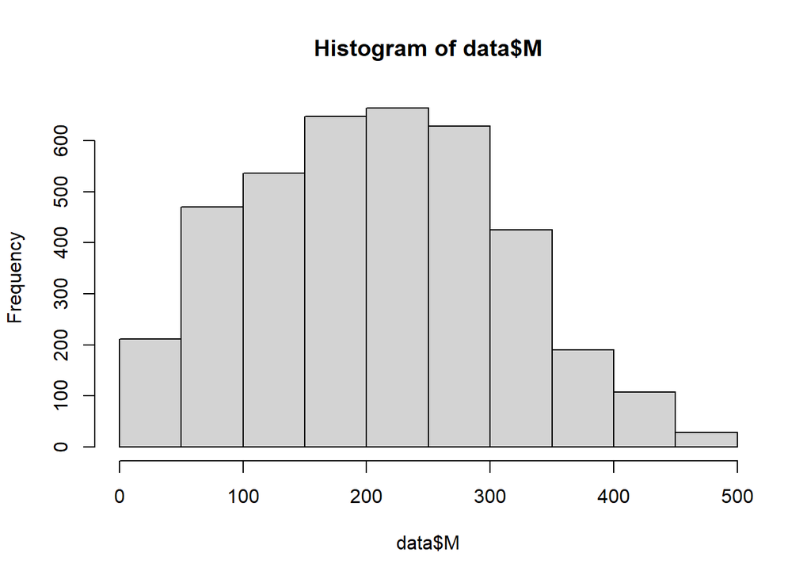

```r
hist(data$M)
```

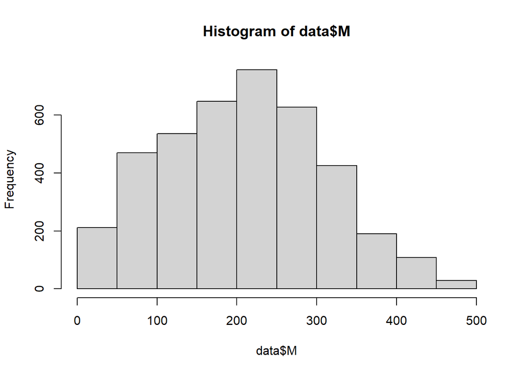

```r
data$M <- ifelse(data$M=="",NA,data$M)
data$R <- ifelse(data$R=="",NA,data$R)
data$F <- ifelse(data$F=="",NA,data$F)
data$M[is.na(data$M)]<- mean(data$M,na.rm =TRUE)
hist(data$M)
```

#column 2

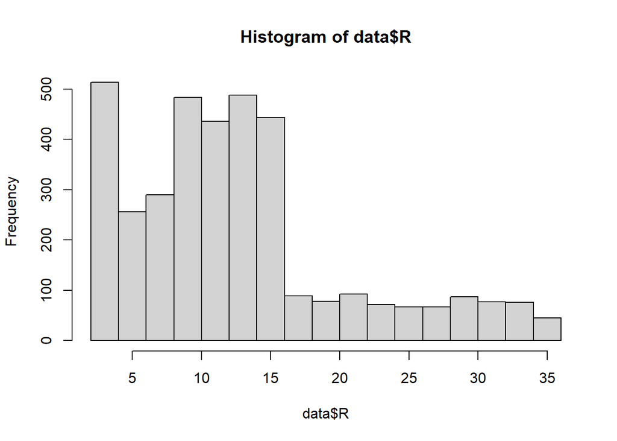

```r
hist(data$R)
```

```r
calcmode <-function(x)
{
  distinct_values <- unique(x)
  distinct_tab<-tabulate(match(x,distinct_values))
  distinct_values[which.max(distinct_tab)]
}

data$R <- ifelse(is.na(data$R),calcmode((data$R)),data$R)
head(data)
```

| ...1 | Seq# | ID# | Gender | M | R | F | FirstPurch | ChildBks | YouthBks | CookBks | DoItYBks | RefBks | ArtBks | GeogBks | ItalCook | ItalAtlas | ItalArt | Florence | Related Purchase | Yes_Florence | No_Florence | Name | Phone_No. | Address | Job |
| --- | --- | --- | --- | --- | --- | --- | --- | --- | --- | --- | --- | --- | --- | --- | --- | --- | --- | --- | --- | --- | --- | --- | --- | --- | --- |
| 0 | 1 | 25 | 1 | 297 | 14 | 2 | 22 | 0 | 1 | 1 | 0 | 0 | 0 | 0 | 0 | 0 | 0 | 0 | 0 | 0 | 1 | David Myers | 001-791-399-5315x363 | 888 Megan Knoll Apt. 557\nLake Desireeton, VT 29179 | Engineer, control and instrumentation |
| 1 | 2 | 29 | 0 | 128 | 8 | 2 | 10 | 0 | 0 | 0 | 0 | 0 | 0 | 0 | 0 | 0 | 0 | 0 | 0 | 0 | 1 | Joseph Martinez | 457-853-5414x5862 | PSC 7668, Box 1389\nAPO AP 02993 | Civil Service fast streamer |
| 2 | 3 | 46 | 1 | 138 | 22 | 7 | 56 | 2 | 1 | 2 | 0 | 1 | 0 | 1 | 1 | 0 | 0 | 0 | 2 | 0 | 1 | Mary Robertson | 001-158-219-2072 | PSC 9260, Box 3091\nAPO AA 38639 | Designer, exhibition/display |
| 3 | 4 | 47 | 1 | 228 | 2 | 1 | 2 | 0 | 0 | 0 | 0 | 0 | 0 | 0 | 0 | 0 | 0 | 0 | 0 | 0 | 1 | Donna Brown | (294)715-2124 | 833 Michael Meadow Suite 594\nJennifermouth, NH 50940 | Lawyer |
| 4 | 5 | 51 | 1 | 257 | 10 | 1 | 10 | 0 | 0 | 0 | 0 | 0 | 0 | 0 | 0 | 0 | 0 | 0 | 0 | 0 | 1 | Nicholas Cook | 347.504.7480x55105 | 35509 Villegas Lane\nEast Karenville, MT 73633 | Data scientist |
| 5 | 6 | 60 | 1 | 145 | 6 | 2 | 12 | 0 | 0 | 0 | 0 | 0 | 0 | 0 | 0 | 0 | 0 | 0 | 0 | 0 | 1 | Rachel Stewart | 725.452.9784x18338 | 6305 David Fall Apt. 100\nLake Russell, KY 46819 | Conservation officer, nature |

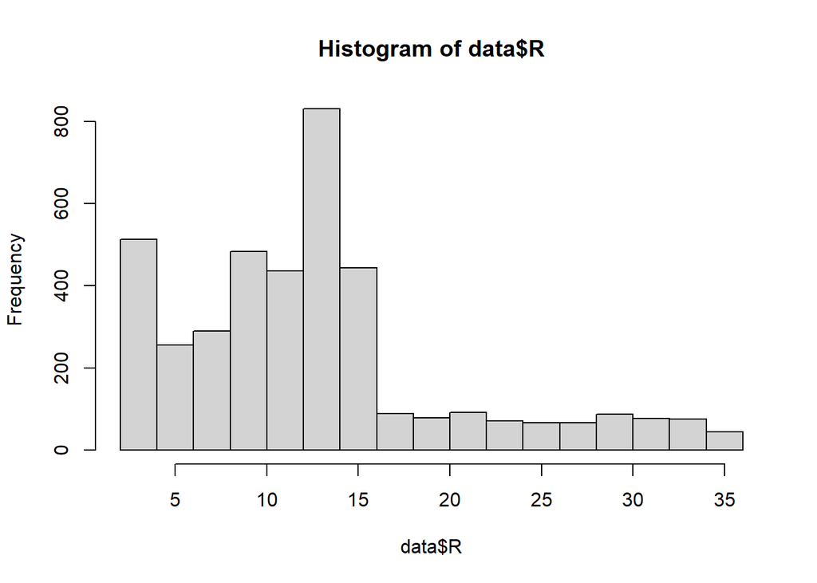

```r
hist(data$R)
```

#column 3

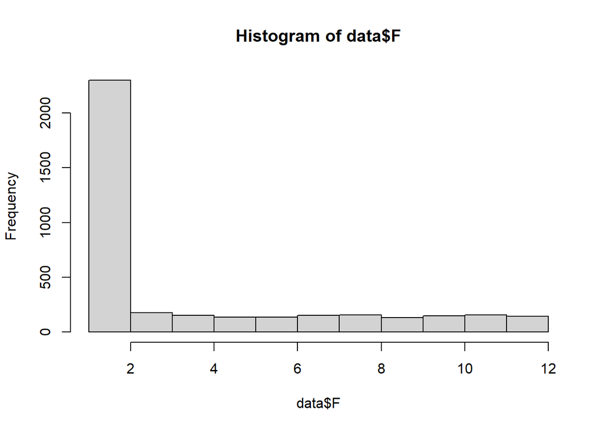

```r
hist(data$F)
```

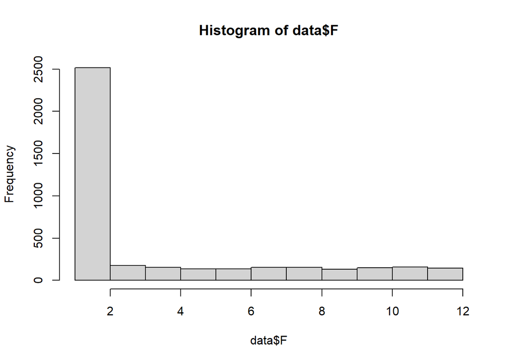

```r
data$F <- ifelse(is.na(data$F),calcmode((data$F)),data$F)
hist(data$F)
```

#problem 3 Discretize the continuous values of Monetary, Recency, and Frequency into appropriate bins, and create three new columns Mcode, Rcode and Fcode respectively, for the discretized values. Explicitly mention the number of bins used and explain the choice for the bin size. Print out the summary of the newly created columns. Hint: Use the cut function to break on preset breakpoints. What are the most optimum breakpoints you can choose? Try to think of a statistical function that provides these breakpoints for optimum binning.

```r
data$Rnewcol <- cut(data$R, breaks=5)
data$Mnewcol <- cut(data$M, breaks=5)
data$Fnewcol <- cut(data$F, breaks=5)
summary(data)
```

```
##       ...1             Seq#           ID#            Gender
##  Min.   :   0.0   Min.   :   1   Min.   :   25   Min.   :0.0000
##  1st Qu.: 999.8   1st Qu.:1001   1st Qu.: 8253   1st Qu.:0.0000
##  Median :1999.5   Median :2000   Median :16581   Median :1.0000
##  Mean   :1999.5   Mean   :2000   Mean   :16595   Mean   :0.7045
##  3rd Qu.:2999.2   3rd Qu.:3000   3rd Qu.:24838   3rd Qu.:1.0000
##  Max.   :3999.0   Max.   :4000   Max.   :32977   Max.   :1.0000
##        M               R               F            FirstPurch
##  Min.   : 15.0   Min.   : 2.00   Min.   : 1.000   Min.   : 2.00
##  1st Qu.:131.0   1st Qu.: 8.00   1st Qu.: 1.000   1st Qu.:12.00
##  Median :208.2   Median :14.00   Median : 2.000   Median :20.00
##  Mean   :208.2   Mean   :13.48   Mean   : 3.677   Mean   :26.51
##  3rd Qu.:281.0   3rd Qu.:16.00   3rd Qu.: 6.000   3rd Qu.:36.00
##  Max.   :479.0   Max.   :36.00   Max.   :12.000   Max.   :99.00
##     ChildBks         YouthBks         CookBks          DoItYBks
##  Min.   :0.0000   Min.   :0.0000   Min.   :0.0000   Min.   :0.0000
##  1st Qu.:0.0000   1st Qu.:0.0000   1st Qu.:0.0000   1st Qu.:0.0000
##  Median :0.0000   Median :0.0000   Median :0.0000   Median :0.0000
##  Mean   :0.6398   Mean   :0.3048   Mean   :0.7312   Mean   :0.3508
##  3rd Qu.:1.0000   3rd Qu.:0.0000   3rd Qu.:1.0000   3rd Qu.:1.0000
##  Max.   :7.0000   Max.   :5.0000   Max.   :7.0000   Max.   :5.0000
##      RefBks           ArtBks         GeogBks          ItalCook
##  Min.   :0.0000   Min.   :0.000   Min.   :0.0000   Min.   :0.0000
##  1st Qu.:0.0000   1st Qu.:0.000   1st Qu.:0.0000   1st Qu.:0.0000
##  Median :0.0000   Median :0.000   Median :0.0000   Median :0.0000
##  Mean   :0.2562   Mean   :0.289   Mean   :0.3875   Mean   :0.1252
##  3rd Qu.:0.0000   3rd Qu.:0.000   3rd Qu.:1.0000   3rd Qu.:0.0000
##  Max.   :4.0000   Max.   :5.000   Max.   :6.0000   Max.   :3.0000
##    ItalAtlas         ItalArt           Florence      Related Purchase
##  Min.   :0.0000   Min.   :0.00000   Min.   :0.0000   Min.   :0.000
##  1st Qu.:0.0000   1st Qu.:0.00000   1st Qu.:0.0000   1st Qu.:0.000
##  Median :0.0000   Median :0.00000   Median :0.0000   Median :0.000
##  Mean   :0.0375   Mean   :0.04575   Mean   :0.0845   Mean   :0.885
##  3rd Qu.:0.0000   3rd Qu.:0.00000   3rd Qu.:0.0000   3rd Qu.:1.000
##  Max.   :2.0000   Max.   :2.00000   Max.   :1.0000   Max.   :8.000
##   Yes_Florence     No_Florence         Name            Phone_No.
##  Min.   :0.0000   Min.   :0.0000   Length:4000        Length:4000
##  1st Qu.:0.0000   1st Qu.:1.0000   Class :character   Class :character
##  Median :0.0000   Median :1.0000   Mode  :character   Mode  :character
##  Mean   :0.0845   Mean   :0.9155
##  3rd Qu.:0.0000   3rd Qu.:1.0000
##  Max.   :1.0000   Max.   :1.0000
##    Address              Job                   Rnewcol           Mnewcol
##  Length:4000        Length:4000        (1.97,8.8] :1059   (14.5,108]: 753
##  Class :character   Class :character   (8.8,15.6] :1749   (108,201] :1112
##  Mode  :character   Mode  :character   (15.6,22.4]: 702   (201,293] :1295
##                                        (22.4,29.2]: 205   (293,386] : 660
##                                        (29.2,36]  : 285   (386,479] : 180
##
##         Fnewcol
##  (0.989,3.2]:2690
##  (3.2,5.4]  : 287
##  (5.4,7.6]  : 287
##  (7.6,9.8]  : 285
##  (9.8,12]   : 451
##
```

### Problem 4

The marketing team heavily relies on the RFM variables of the recency of last purchase, total number of purchases, and total money spent on purchases to gauge the health of the members of the book club. Increases in either the frequency of purchases or monetary spend and decreases in time since last purchase across the customer base, will intuitively lead to more sales for the business.

#### 4.1 Bar Graphs (1 point)

Create and visualize histograms for the discretized Recency, Frequency, Monetary features. Also create one for the `FirstPurch` feature.

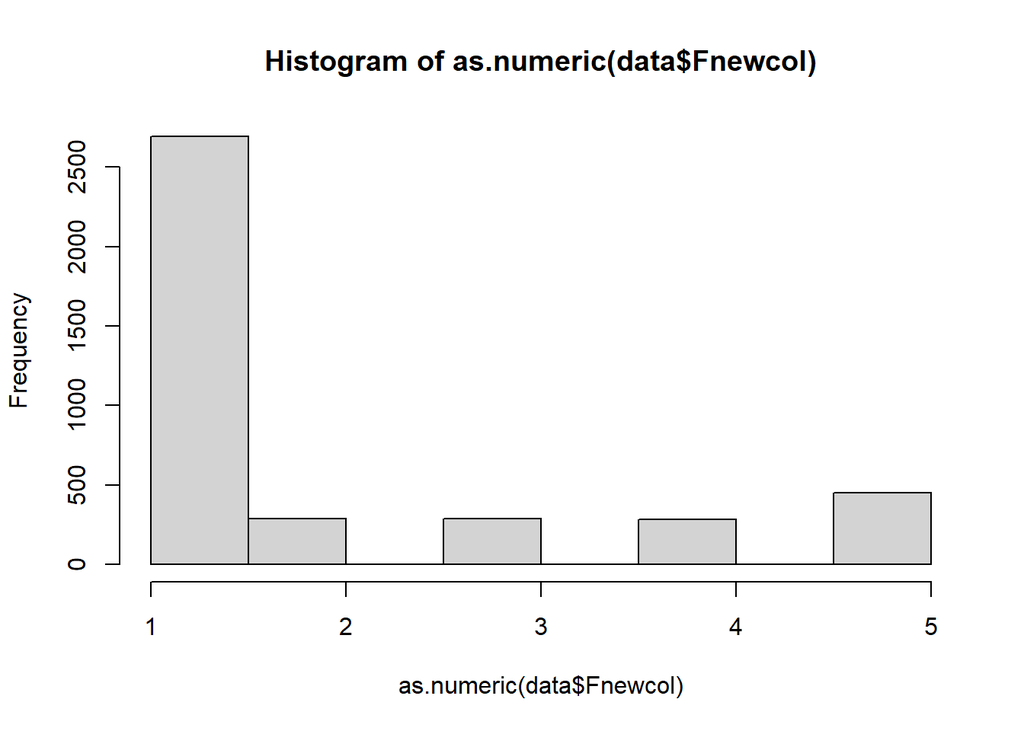

```r
hist(as.numeric(data$Fnewcol))
```

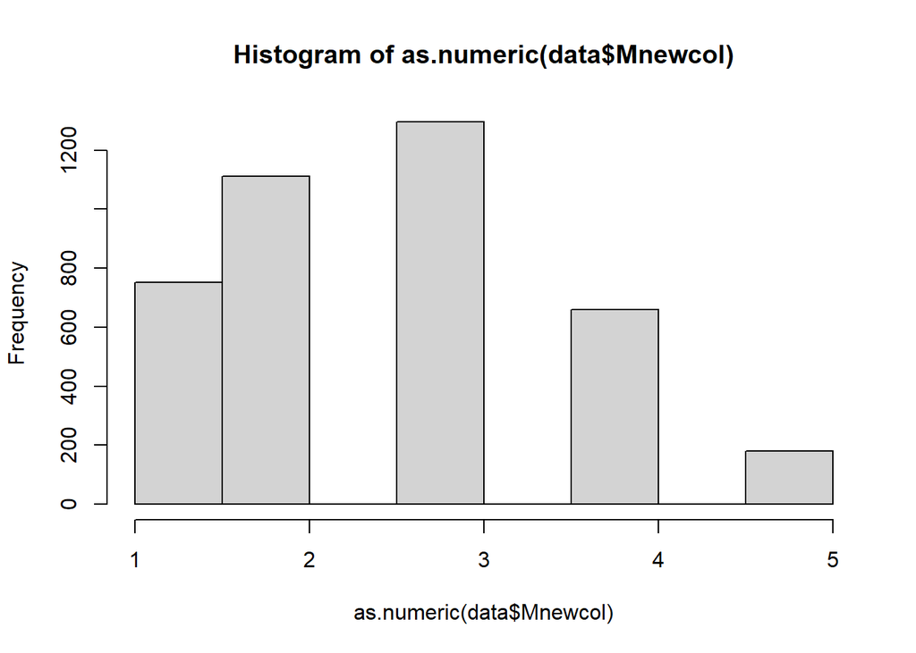

```r
hist(as.numeric(data$Mnewcol))
```

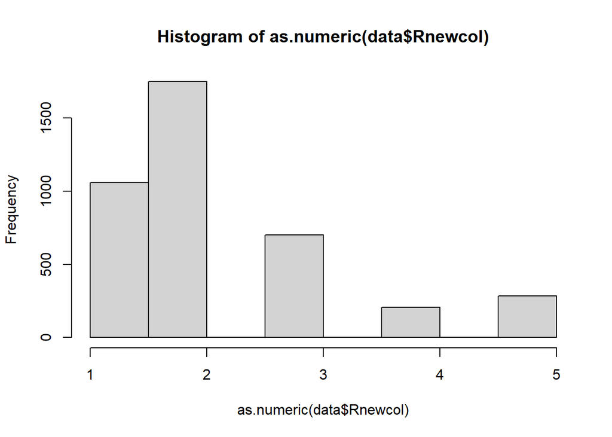

```r
hist(as.numeric(data$Rnewcol))
```

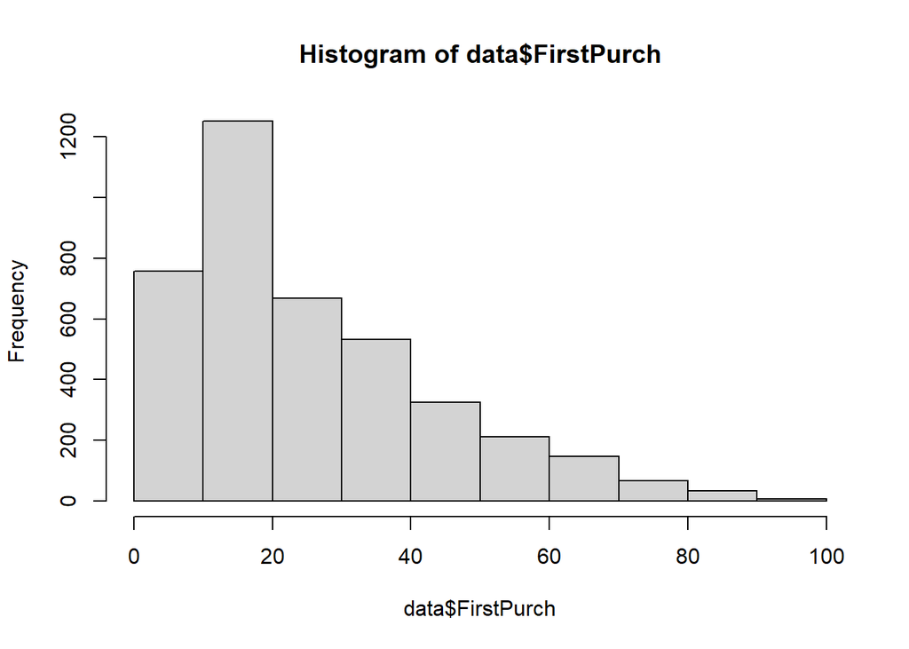

```r
hist(data$FirstPurch)
```

#### 4.3 Density Plot (1 point)

Create and visualize a density plot for Recency, Frequency, Monetary and `FirstPurch` features.

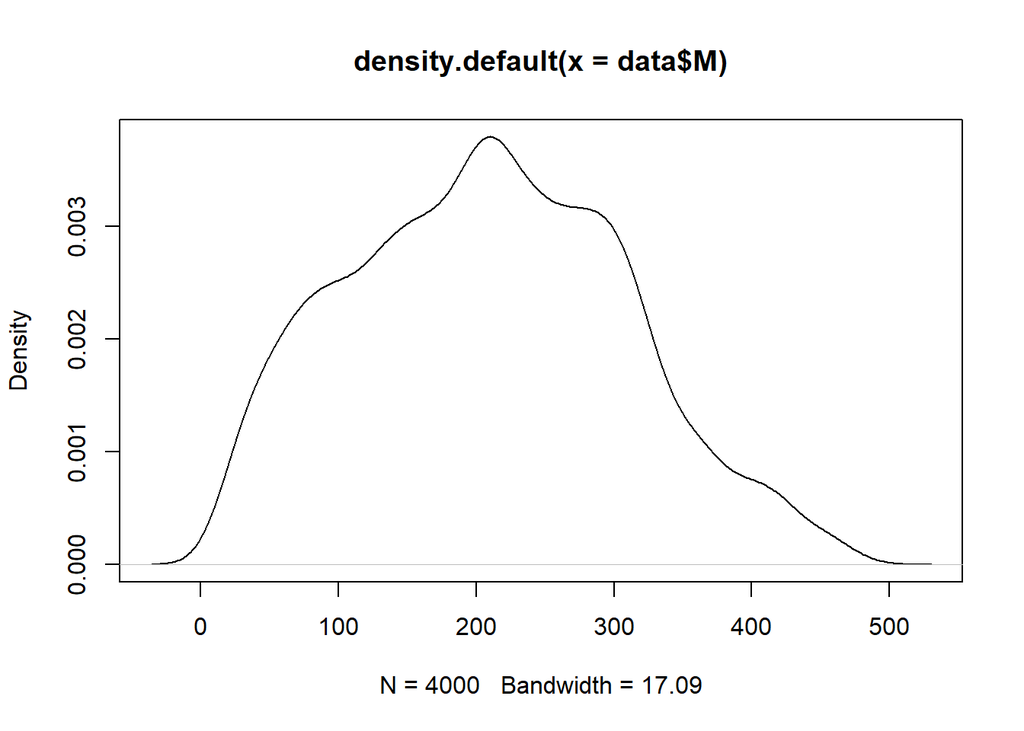

```r
plot(density(data$M))
```

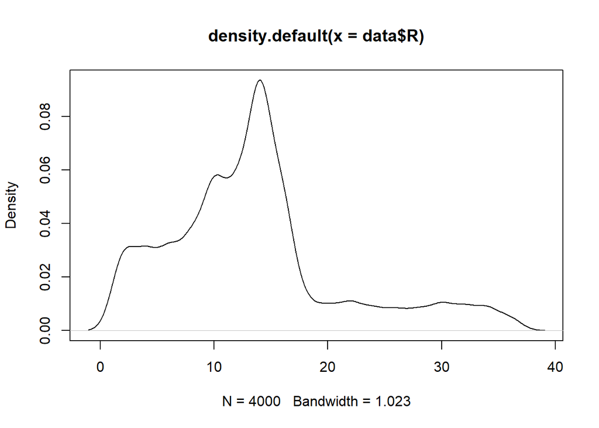

```r
plot(density(data$R))
```

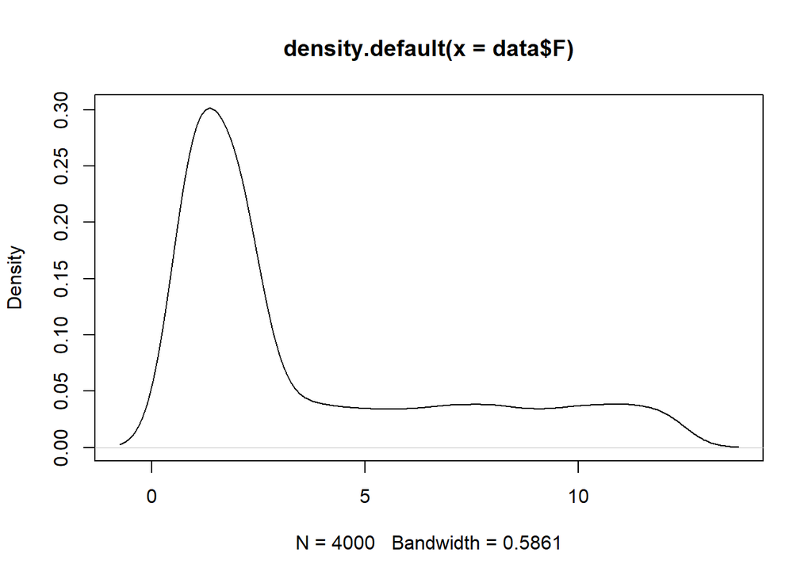

```r
plot(density(data$F))
```

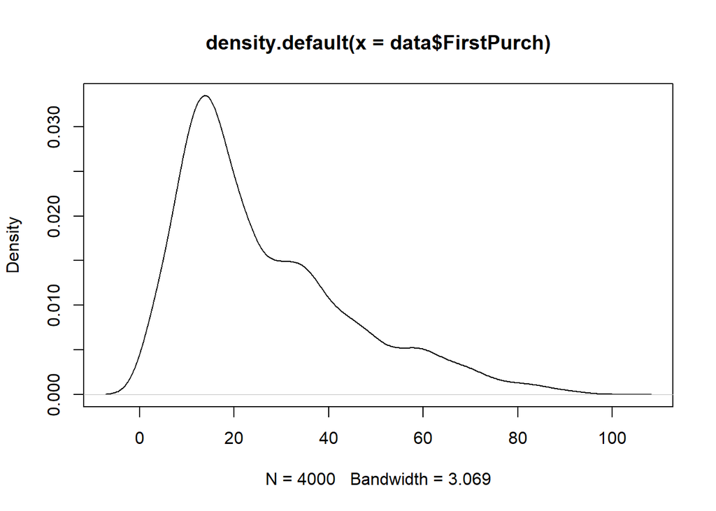

```r
plot(density(data$FirstPurch))
```

# Part II. ANOVA

## Scenario 1

It’s a brand new day in the 99th precinct of the New York Police Department. Lieutenant Terrance has had enough of Hitchcock and Scully being useless paper pushers and wanted to assign them work to help the investigations; they were assigned the duty of gaining insights from the different types of objects in the evidence log of an ongoing investigation focused on the New York Mafia.

## Problems

### Problem 1 (2 points)

Captain Holt provided a file containing the names of a few `People of Interest` and the number of items logged at various evidence lockers of various precincts pertaining to them. He also instructs Peralta and Diaz to look into the file as he was told it should contain more information.

Scully decided to use ANOVA.

For this problem, use the data file named `Scenario 1.csv` in the data repository. Load the following libraries before moving on and read the dataset,

```r
library(ggpubr)
library(dplyr)
library(ggplot2)
library(ggpubr)
library(broom)
library(car)
data <- read.csv('Scenario 1.csv')
oneway<- aov(No.of.items ~ POI, data=data)
summary(oneway)
```

```
##              Df Sum Sq Mean Sq F value Pr(>F)
## POI           4    127   31.75   1.025  0.393
## Residuals   995  30827   30.98
```

1. Consider the dataset. Which type of ANOVA can Scully use? (Justify why the particular test)
2. What function(s) could have been used by Scully for ANOVA if he uses the R programming language?
3. What does the output of this/these functions tell Scully? (Specify hypotheses and what each column in the summary of the output means considering 5% significance)

### Problem 2 (3 points)

Peralta and Diaz find a member of the family, a certain Frank Pentangeli, through Doug Judy. They discovered that the *famiglia* had altered this file resulting in invalid results. The original file was then recovered by the squad and was sent to Scully and Hitchcock for analysis. To their surprise they discovered that the file also had additional column of which gives the priority.

Read the dataset before moving on. For this problem, use the data file named `Scenario 2.csv` in the data repository.

```r
data <- read.csv('Scenario 2.csv')
twoway <- aov(No.of.items ~ POI + Priority, data=data)
summary(twoway)
```

```
##              Df Sum Sq Mean Sq F value   Pr(>F)
## POI           4    317   79.29   2.890   0.0214 *
## Priority      4    690  172.53   6.289 5.35e-05 ***
## Residuals   991  27186   27.43
## ---
## Signif. codes:  0 '***' 0.001 '**' 0.01 '*' 0.05 '.' 0.1 ' ' 1
```

1. Consider the data. Which type of ANOVA can Scully use? (Justify why the particular test)
2. What function(s) could have been used by Scully for the ANOVA if he uses the R programming language?
3. What does the output of this/these functions tell Scully? (Specify hypotheses and what each column in the summary of the output means considering 5% significance)
4. Hitchcock thinks that Scully has missed a task which completes the ANOVA test. What should Scully have thought of? *Hint:* Philosophically, a hypothesis is a proposition made as a basis for reasoning, without any assumption of its truth.

### Problem 3 (1 point)

Hitchcock also wanted to compare the number of items collected for each pair of Person of Interest and priority. He decided to follow the common practice of doing a **Tukey’s HSD** . The [Tukey’s Honestly-Significant-Difference](https://www.real-statistics.com/one-way-analysis-of-variance-anova/unplanned-comparisons/tukey-hsd/)[TukeyHSD] test lets us see which groups are different from one another.

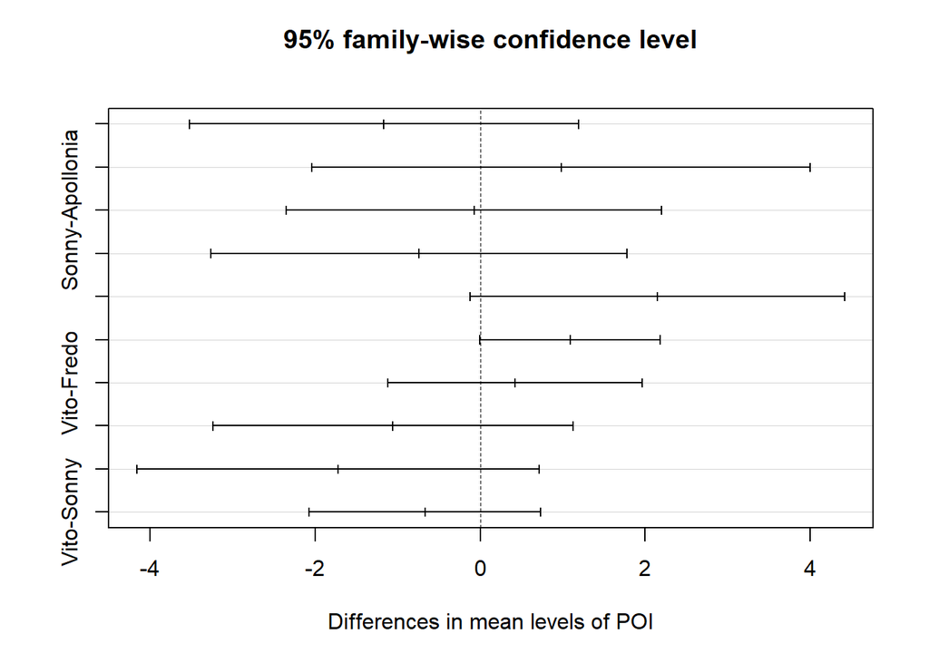

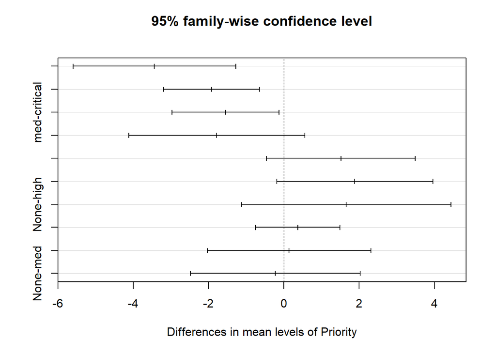

```r
plot(TukeyHSD(twoway,conf.level = 0.95))
```

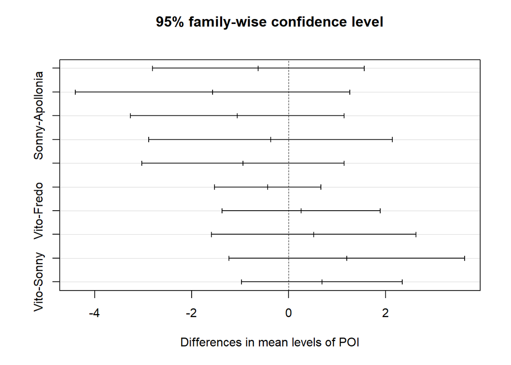

```r
plot(TukeyHSD(oneway,conf.level = 0.95))
```

What insights did Hitchcock gain after doing the Tukey’s HSD? (This test can be done by ‘Tukey’s HSD’ function and the graphical output can be shown using the plot function..-)